# R Notebook

```r
library(car)
```

# Visualisation

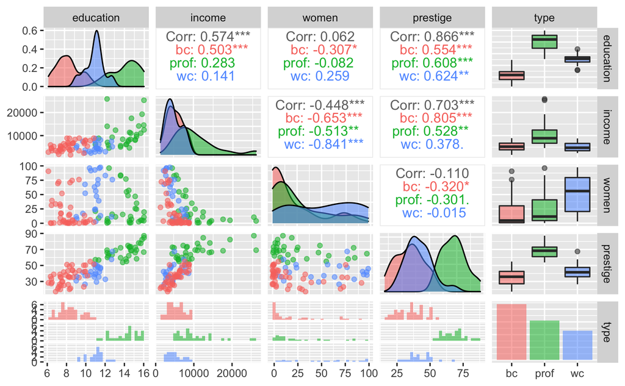

Type, income and education looks significant.

# Compare education and type to see which is most significant

Predict prestige from education

```r
summary(modla)
```

```
Call:
lm(formula = prestige ~ education, data = prestige_trim)

Residuals:
    Min      1Q  Median      3Q     Max
-21.605  -6.151   0.366   6.565  17.540

Coefficients:
            Estimate Std. Error t value Pr(>|t|)
(Intercept) -10.8409     3.5285  -3.072  0.00276 **
education     5.3884     0.3168  17.006  < 2e-16 ***
---
Signif. codes:  0 ‘***’ 0.001 ‘**’ 0.01 ‘*’ 0.05 ‘.’ 0.1 ‘ ’ 1

Residual standard error: 8.578 on 96 degrees of freedom
Multiple R-squared:  0.7508,    Adjusted R-squared:  0.7482
F-statistic: 289.2 on 1 and 96 DF,  p-value: < 2.2e-16
```

Plot

```
`arrange_()` is deprecated as of dplyr 0.7.0.
Please use `arrange()` instead.
See vignette('programming') for more help
```

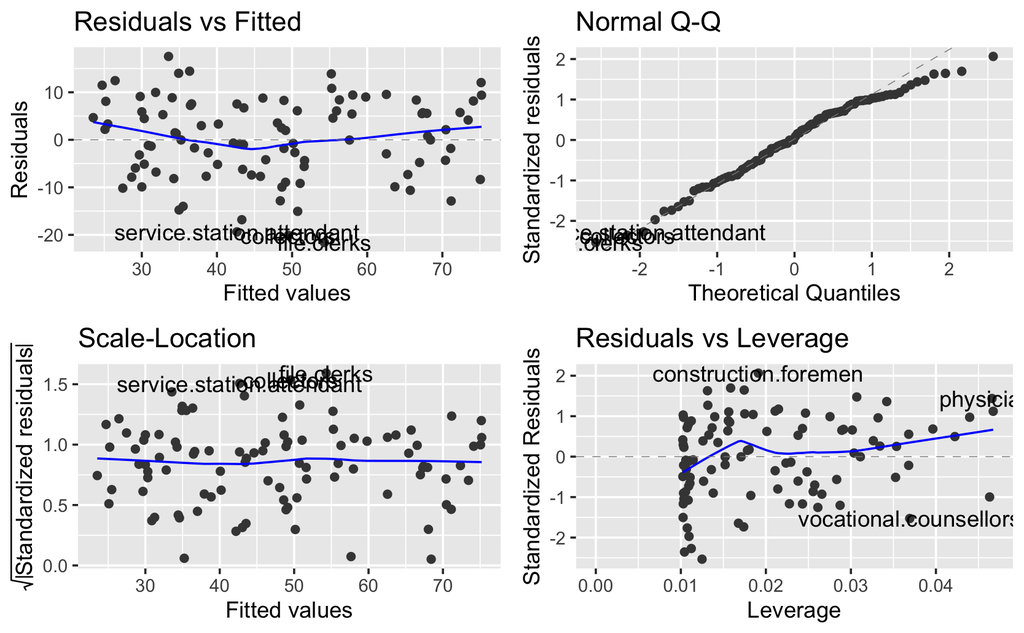

```r
autoplot(modla)
```

[figure not shown]

# Second predictor

Find the stuff which is NOT explained by education

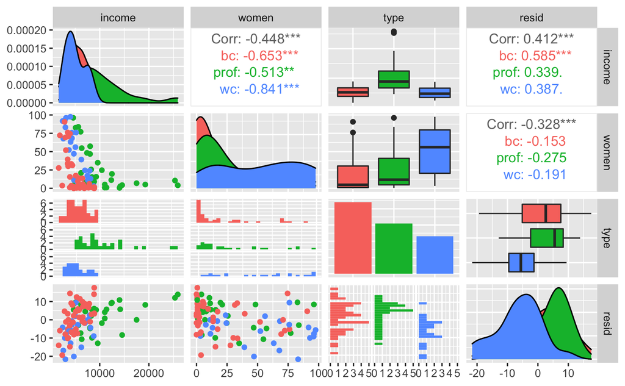

## Test second predictor - income vs type

```r
model_education_income <- lm(prestige ~ education + income, data = prestige_trim)
summary(model_education_income)
```

```
Call:
lm(formula = prestige ~ education + income, data = prestige_trim)

Residuals:
     Min       1Q   Median       3Q      Max
-16.9367  -4.8881   0.0116   4.9690  15.9280

Coefficients:
              Estimate Std. Error t value Pr(>|t|)
(Intercept) -7.6210352  3.1162309  -2.446   0.0163 *
education    4.2921076  0.3360645  12.772  < 2e-16 ***
income       0.0012415  0.0002185   5.682 1.45e-07 ***
---
Signif. codes:  0 ‘***’ 0.001 ‘**’ 0.01 ‘*’ 0.05 ‘.’ 0.1 ‘ ’ 1

Residual standard error: 7.45 on 95 degrees of freedom
Multiple R-squared:  0.814, Adjusted R-squared:  0.8101
F-statistic: 207.9 on 2 and 95 DF,  p-value: < 2.2e-16
```

```r
model_education_type <- lm(prestige ~ education + type, data = prestige_trim)
summary(model_education_type)
```

```
Call:
lm(formula = prestige ~ education + type, data = prestige_trim)

Residuals:
    Min      1Q  Median      3Q     Max
-19.410  -5.508   1.360   5.694  17.171

Coefficients:
            Estimate Std. Error t value Pr(>|t|)
(Intercept)  -2.6982     5.7361  -0.470   0.6392
education     4.5728     0.6716   6.809 9.16e-10 ***
typeprof      6.1424     4.2590   1.442   0.1526
typewc       -5.4585     2.6907  -2.029   0.0453 *
---
Signif. codes:  0 ‘***’ 0.001 ‘**’ 0.01 ‘*’ 0.05 ‘.’ 0.1 ‘ ’ 1

Residual standard error: 7.814 on 94 degrees of freedom
Multiple R-squared:  0.7975,    Adjusted R-squared:  0.791
F-statistic: 123.4 on 3 and 94 DF,  p-value: < 2.2e-16
```

Education income performs better than Education type. Mainly based on r-squared.

# ANOVA: Understanding the statistical significance of categorical predictors

Use ANOVA. Analysis of variance (tests for the difference in more than one sample mean) in conjunction with residual variance.

# How significant was type as a predictor variable compared to our model so far?

Null hypothesis: the model with and without type explains the same amount of variance Alternative hypothesis: the models with and without type explain different amounts of variance.

```r
anova(modla, model_education_type)
```

```
Analysis of Variance Table

Model 1: prestige ~ education
Model 2: prestige ~ education + type
  Res.Df    RSS Df Sum of Sq      F    Pr(>F)
1     96 7064.4
2     94 5740.0  2    1324.4 10.844 5.787e-05 ***
---
Signif. codes:  0 ‘***’ 0.001 ‘**’ 0.01 ‘*’ 0.05 ‘.’ 0.1 ‘ ’ 1
```

Type is significant.

So far: - education: including - income: including - type: after checking whether type as a whole (rather than just one type) is significant, we will now check whether adding type to our model is helpful

# Check residuals so far

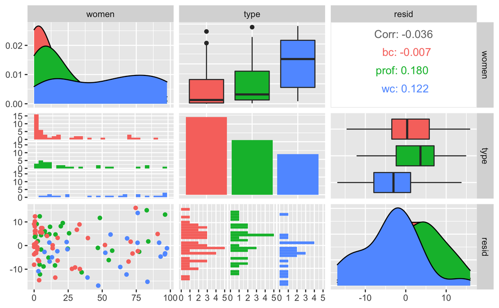

# Add a third predictor

```r
summary(model_edu_inc_type)
```

```
Call:
lm(formula = prestige ~ education + income + type, data = prestige_trim)

Residuals:
     Min       1Q   Median       3Q      Max
-14.9529  -4.4486   0.1678   5.0566  18.6320

Coefficients:
              Estimate Std. Error t value Pr(>|t|)
(Intercept) -0.6229292  5.2275255  -0.119    0.905
education    3.6731661  0.6405016   5.735 1.21e-07 ***
income       0.0010132  0.0002209   4.586 1.40e-05 ***
typeprof     6.0389707  3.8668551   1.562    0.122
typewc      -2.7372307  2.5139324  -1.089    0.279
---
Signif. codes:  0 ‘***’ 0.001 ‘**’ 0.01 ‘*’ 0.05 ‘.’ 0.1 ‘ ’ 1

Residual standard error: 7.095 on 93 degrees of freedom
Multiple R-squared:  0.8349,    Adjusted R-squared:  0.8278
F-statistic: 117.5 on 4 and 93 DF,  p-value: < 2.2e-16
```

We increase r squared and decrease residual, but our type predictors look insignificant

# So compare model_edu_inc with model_edu_inc_type. This will tell us whether there is a statistical difference between the amount of variance explained by each model.

```r
anova(model_education_income, model_edu_inc_type)
```

```
Analysis of Variance Table

Model 1: prestige ~ education + income
Model 2: prestige ~ education + income + type
  Res.Df    RSS Df Sum of Sq      F   Pr(>F)
1     95 5272.4
2     93 4681.3  2    591.16 5.8721 0.003966 **
---
Signif. codes:  0 ‘***’ 0.001 ‘**’ 0.01 ‘*’ 0.05 ‘.’ 0.1 ‘ ’ 1
```

The model with type is statistically different to the model without type so we will include that predictor variable.

# Interactions

Best practice says that we should only include an interaction between variables that we have already included in our model. Let’s compare education:income, education:type and income:type to see which interaction will improve our model.

## Look at residuals without prestige

## Visualise residuals against interactions

Income | education

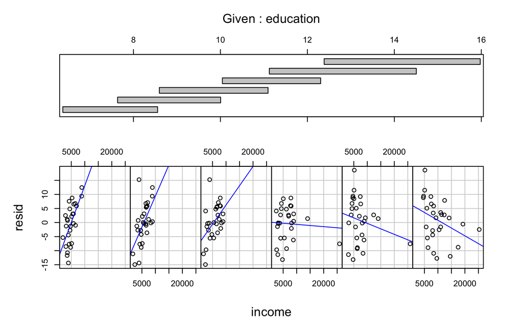

```r
coplot(resid ~ income | education,
       # add trend line
       panel = function(x, y, ...) {
         points(x, y)
         abline(lm(y ~ x), col = "blue")
       },
       data = prestige_remaining_resid, columns = 6)
```

The variance in trend lines indicates that this might be a useful interaction.

education | type We can use ggplot here as type is categorical

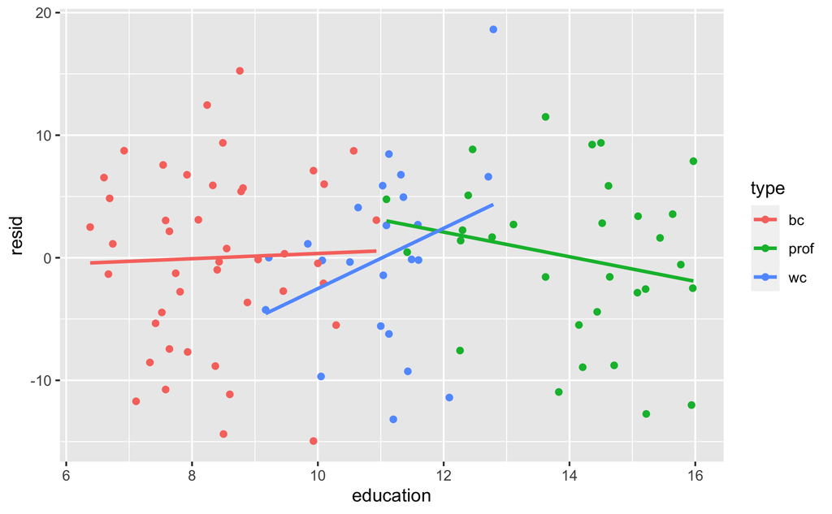

Also looks promising

Income | Type

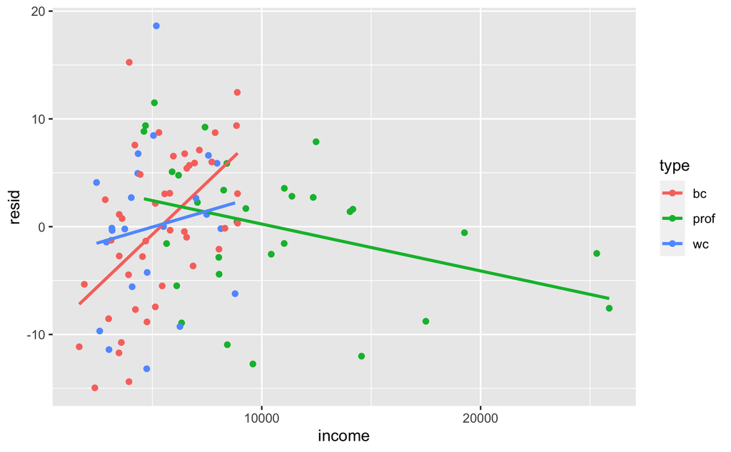

```r
prestige_remaining_resid %>%
  ggplot(aes(x = income, y = resid, colour = type)) +
  geom_point() +
  geom_smooth(method = "lm", se = FALSE)
```

Also promising

## Test these three interactions

education:type

```r
model_edu_inc_type_eduandtype <- lm(prestige ~ education + income + type + education:type,
                                   data = prestige_trim)

summary(model_edu_inc_type_eduandtype)
```

```
Call:
lm(formula = prestige ~ education + income + type + education:type,
    data = prestige_trim)

Residuals:
     Min       1Q   Median       3Q      Max
-15.1168  -4.1751   0.4384   5.1625  15.2362

Coefficients:
                     Estimate Std. Error t value Pr(>|t|)
(Intercept)        -2.331e+00  7.783e+00  -0.299    0.765
education           3.852e+00  9.406e-01   4.096 9.12e-05 ***
income              1.052e-03  2.201e-04   4.782 6.66e-06 ***
typeprof            2.209e+01  1.520e+01   1.454    0.149
typewc             -2.822e+01  1.959e+01  -1.440    0.153
education:typeprof -1.227e+00  1.304e+00  -0.941    0.349
education:typewc    2.270e+00  1.872e+00   1.213    0.228
---
Signif. codes:  0 ‘***’ 0.001 ‘**’ 0.01 ‘*’ 0.05 ‘.’ 0.1 ‘ ’ 1

Residual standard error: 7.036 on 91 degrees of freedom
Multiple R-squared:  0.8411,    Adjusted R-squared:  0.8306
F-statistic: 80.27 on 6 and 91 DF,  p-value: < 2.2e-16
```

Slightly better than existing model. our education:type does not look significant though.

```r
anova(model_edu_inc_type, model_edu_inc_type_eduandtype)
```

```
Analysis of Variance Table

Model 1: prestige ~ education + income + type
Model 2: prestige ~ education + income + type + education:type
  Res.Df    RSS Df Sum of Sq      F Pr(>F)
1     93 4681.3
2     91 4504.6  2    176.65 1.7842 0.1737
```

Not significant.

education:income

```r
model_edu_inc_type_eduandinc <- lm(prestige ~ education + income + type + education:income,
                                   data = prestige_trim)

summary(model_edu_inc_type_eduandinc)
```

```
Call:
lm(formula = prestige ~ education + income + type + education:income,
    data = prestige_trim)

Residuals:
     Min       1Q   Median       3Q      Max
-13.6084  -5.0225   0.3531   4.9346  17.9175

Coefficients:
                   Estimate Std. Error t value Pr(>|t|)
(Intercept)      -1.780e+01  7.594e+00  -2.344 0.021212 *
education         5.104e+00  7.766e-01   6.572 2.93e-09 ***
income            3.786e-03  9.445e-04   4.008 0.000124 ***
typeprof          5.479e+00  3.714e+00   1.475 0.143574
typewc           -3.584e+00  2.428e+00  -1.476 0.143303
education:income -2.102e-04  6.977e-05  -3.012 0.003347 **
---
Signif. codes:  0 ‘***’ 0.001 ‘**’ 0.01 ‘*’ 0.05 ‘.’ 0.1 ‘ ’ 1

Residual standard error: 6.806 on 92 degrees of freedom
Multiple R-squared:  0.8497,    Adjusted R-squared:  0.8415
F-statistic:   104 on 5 and 92 DF,  p-value: < 2.2e-16
```

Standard error has decreased more than with previous model and our new test looks significant.

```r
anova(model_edu_inc_type, model_edu_inc_type_eduandinc)
```

```
Analysis of Variance Table

Model 1: prestige ~ education + income + type
Model 2: prestige ~ education + income + type + education:income
  Res.Df    RSS Df Sum of Sq      F   Pr(>F)
1     93 4681.3
2     92 4261.0  1    420.28 9.0744 0.003347 **
---
Signif. codes:  0 ‘***’ 0.001 ‘**’ 0.01 ‘*’ 0.05 ‘.’ 0.1 ‘ ’ 1
```

Significant.

income:type

```r
model_edu_inc_type_incandtype <- lm(prestige ~ education + income + type + income:type,
                                   data = prestige_trim)

summary(model_edu_inc_type_incandtype)
```

```
Call:
lm(formula = prestige ~ education + income + type + income:type,
    data = prestige_trim)

Residuals:
     Min       1Q   Median       3Q      Max
-12.8720  -4.8321   0.8534   4.1425  19.6710

Coefficients:
                  Estimate Std. Error t value Pr(>|t|)
(Intercept)     -6.7272633  4.9515480  -1.359   0.1776
education        3.0396961  0.6003699   5.063 2.14e-06 ***
income           0.0031344  0.0005215   6.010 3.79e-08 ***
typeprof        25.1723873  5.4669586   4.604 1.34e-05 ***
typewc           7.1375093  5.2898177   1.349   0.1806
income:typeprof -0.0025102  0.0005530  -4.539 1.72e-05 ***
income:typewc   -0.0014856  0.0008720  -1.704   0.0919 .
---
Signif. codes:  0 ‘***’ 0.001 ‘**’ 0.01 ‘*’ 0.05 ‘.’ 0.1 ‘ ’ 1

Residual standard error: 6.455 on 91 degrees of freedom
Multiple R-squared:  0.8663,    Adjusted R-squared:  0.8574
F-statistic: 98.23 on 6 and 91 DF,  p-value: < 2.2e-16
```

```r
anova(model_edu_inc_type, model_edu_inc_type_incandtype)
```

```
Analysis of Variance Table

Model 1: prestige ~ education + income + type
Model 2: prestige ~ education + income + type + income:type
  Res.Df    RSS Df Sum of Sq      F    Pr(>F)
1     93 4681.3
2     91 3791.3  2    890.02 10.681 6.809e-05 ***
---
Signif. codes:  0 ‘***’ 0.001 ‘**’ 0.01 ‘*’ 0.05 ‘.’ 0.1 ‘ ’ 1
```

More significant difference than the previous two models.

I will make income:type the new model.

# Relative importance analysis

How do we measure the influence of each predictor variable relative to the others?

We use relative importance analysis to split the r squared value across the component predictor variables. The higher the proportion of r squared assigned to a variable, the greater that variables impact on explaining the response variable.

```r
library(relaimpo)

calc.relimp(model_edu_inc_type_incandtype,
            # Set type of measurement
            type = "lmg",
            # ensure values add up to 100%
            rela = TRUE)
```

```
Response variable: prestige
Total response variance: 292.2358
Analysis based on 98 observations

6 Regressors:
Some regressors combined in groups:
        Group  type : typeprof typewc
        Group  income:type : income:typeprof income:typewc

 Relative importance of 4 (groups of) regressors assessed:
 type income:type education income

Proportion of variance explained by model: 86.63%
Metrics are normalized to sum to 100% (rela=TRUE).

Relative importance metrics:

                   lmg
type        0.39609310
income:type 0.04222622
education   0.30489921
income      0.25678147

Average coefficients for different model sizes:

                      1group      2groups      3groups      4groups
education        5.388407674  4.432450330  3.673166052  3.039696088
income           0.002843574  0.001321366  0.002518339  0.003134410
typeprof        32.321114370 15.598958947 25.528996354 25.172387319
typewc           6.716205534  0.854330301  8.121753937  7.137509272
income:typeprof          NaN          NaN -0.003178285 -0.002510174
income:typewc            NaN          NaN -0.002171217 -0.001485560
```

We can say that type is contributing 40% to the prediction, education 30%, income 25% and income:type 4%.

We can also use beta coefficients, but calc.relimp is better!